# Playing with domestic airline perfomance data

Kirill

April 23, 2020

## Introduction

I found this rather interesting data set at data.gov.au, [Domestic Airlines - On Time Performance](https://data.gov.au/data/dataset/domestic-airline-on-time-performance) and I decided to investigate it a bit closer.

First thing first is to download it. Note that `read_csv` from [`readr`](https://readr.tidyverse.org/) package can “read” directly from url, but I wasn’t sure if everytime I compile html it would re-download the file or use chached version. The data is *Creative Commons Attribution 3.0 Australia* and so no problem in downloading and using the data.

### Loading libraries

We are going to use

```r
library(tidyverse)
library(knitr)
```

### Downloading the data

We are going to use [`tidyverse`](https://www.tidyverse.org/) library that includes several other useful libraries, such as:

- `readr`
- `tidyr`
- `dplyr`
- `ggplot2`

to name a few

Note that we are doing conditional download here, obviously don’t want to re-download if we already have the file.

```r
fn_data <- "domestic_airline_performance.csv"
fn_notes <- "domestic_airline_performance_notes.txt"

if(!file.exists(fn_data)) {
  url_data <- "https://data.gov.au/data/dataset/29128ebd-dbaa-4ff5-8b86-d9f30de56452/resource/cf663ed1-0c5e-497f-aea9-e74bfda9cf44/download/otp_time_series_web.csv"
  url_notes <- "https://data.gov.au/data/dataset/29128ebd-dbaa-4ff5-8b86-d9f30de56452/resource/69e214b9-b66f-4636-9c84-3efda2d0d8ae/download/otptimeserieswebnotes.txt"

  download.file(url_data, fn_data)
  download.file(url_notes, fn_notes)
}

df <- read_csv(fn_data, quote = "")

df
```

| Route | Departing_Port | Arriving_Port | Airline | Month | Sectors_Scheduled | Sectors_Flown | Cancellations | Departures_On_Time | Arrivals_On_Time | Departures_Delayed | Arrivals_Delayed | Year | Month_Num |
| --- | --- | --- | --- | --- | --- | --- | --- | --- | --- | --- | --- | --- | --- |
| Adelaide-Brisbane | Adelaide | Brisbane | All Airlines | 37987 | 155 | 155 | 0 | 123 | 120 | 32 | 35 | 2004 | 1 |
| Adelaide-Canberra | Adelaide | Canberra | All Airlines | 37987 | 75 | 75 | 0 | 72 | 72 | 3 | 3 | 2004 | 1 |
| Adelaide-Gold Coast | Adelaide | Gold Coast | All Airlines | 37987 | 40 | 40 | 0 | 36 | 35 | 4 | 5 | 2004 | 1 |
| Adelaide-Melbourne | Adelaide | Melbourne | All Airlines | 37987 | 550 | 548 | 2 | 478 | 487 | 70 | 61 | 2004 | 1 |
| Adelaide-Perth | Adelaide | Perth | All Airlines | 37987 | 191 | 191 | 0 | 169 | 168 | 22 | 23 | 2004 | 1 |
| Adelaide-Sydney | Adelaide | Sydney | All Airlines | 37987 | 486 | 485 | 1 | 456 | 465 | 29 | 20 | 2004 | 1 |
| Albury-Sydney | Albury | Sydney | All Airlines | 37987 | 168 | 168 | 0 | 148 | 146 | 20 | 22 | 2004 | 1 |
| Alice Springs-Sydney | Alice Springs | Sydney | All Airlines | 37987 | 63 | 63 | 0 | 61 | 63 | 2 | 0 | 2004 | 1 |
| All Ports-All Ports | All Ports | All Ports | All Airlines | 37987 | 31913 | 31685 | 228 | 27599 | 27475 | 4086 | 4210 | 2004 | 1 |
| Brisbane-Adelaide | Brisbane | Adelaide | All Airlines | 37987 | 155 | 155 | 0 | 123 | 140 | 32 | 15 | 2004 | 1 |

[output cut: 9990 more lines]

## Exploring the data

Now that we’ve got the data lets explore it. It always helps if we can find more information about the data set, particular what information each column might have.

### Working with data

```r
d <- df %>% dim
```

total number of observation 80083 and total number of variables 14

There are many ways you can explore this data, but i just want to have a look at the types of Airlines there are.

```r
df %>%
  select(Airline) %>%
  distinct() %>%
  arrange(Airline)
```

| Airline |
| --- |
| All Airlines |
| Jetstar |
| Macair |
| MacAir |
| Ozjet |
| Qantas |
| QantasLink |
| Regional Express |
| Skywest |
| Tigerair Australia |

[output cut: 3 more lines]

## Cleaning up

I’ve noticed that there “All Airlines” name in the `Airline` column that appears to have the most number of occurrences in the data

```r
df %>%
  group_by(Airline) %>%
  summarise(n = n()) %>%
  arrange(-n)
```

| Airline | n |
| --- | --- |
| All Airlines | 20879 |
| Virgin Australia | 18137 |
| Jetstar | 11223 |
| Qantas | 11042 |
| QantasLink | 9551 |
| Tigerair Australia | 3943 |
| Regional Express | 2582 |
| Virgin Australia Regional Airlines | 1632 |
| Skywest | 752 |
| Virgin Australia - ATR/F100 Operations | 290 |

[output cut: 3 more lines]

Also there one of the routes is `All Ports-All Ports`. Googling for that name didn’t reveal any places in Australia by that name.

```r
df %>%
  group_by(Route) %>%
  summarise(n = n()) %>%
  arrange(-n)
```

| Route | n |
| --- | --- |
| All Ports-All Ports | 1497 |
| Broome-Perth | 903 |
| Perth-Broome | 903 |
| Cairns-Brisbane | 902 |
| Brisbane-Cairns | 901 |
| Hobart-Melbourne | 895 |
| Melbourne-Hobart | 895 |
| Adelaide-Sydney | 867 |
| Sydney-Adelaide | 867 |
| Adelaide-Melbourne | 865 |

[output cut: 139 more lines]

I decide going forward to drop those data points.

```r
df2 <- df %>%
          filter(Airline != "All Airlines",
                 Route != "All Ports-All Ports")
```

## Visualising the data

Here we are summarising so that we have an idea of how many times a particular location had be use per airline per year and we are only going to look at two airlines, Jetstar and Qantas.

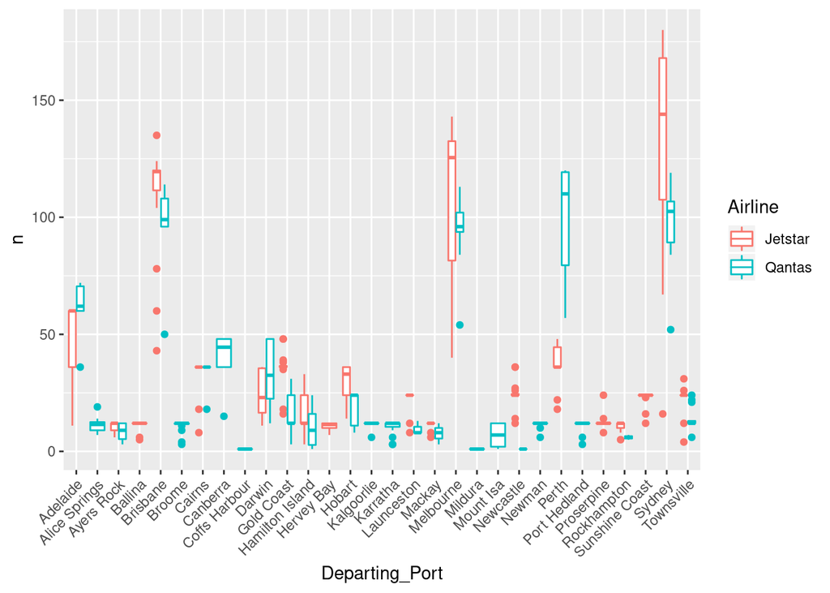

```r
p2 <- df2 %>%
  group_by(Airline, Year, Departing_Port) %>%
  summarise(n = n()) %>%
  ungroup %>%
  filter(Airline == "Jetstar" | Airline == "Qantas") %>%
  ggplot(aes(Departing_Port, n, color = Airline)) +
    geom_boxplot() +
    theme(axis.text.x=element_text(angle=45, hjust=1))

p2
```

In any given year what is the distribution of cancellation

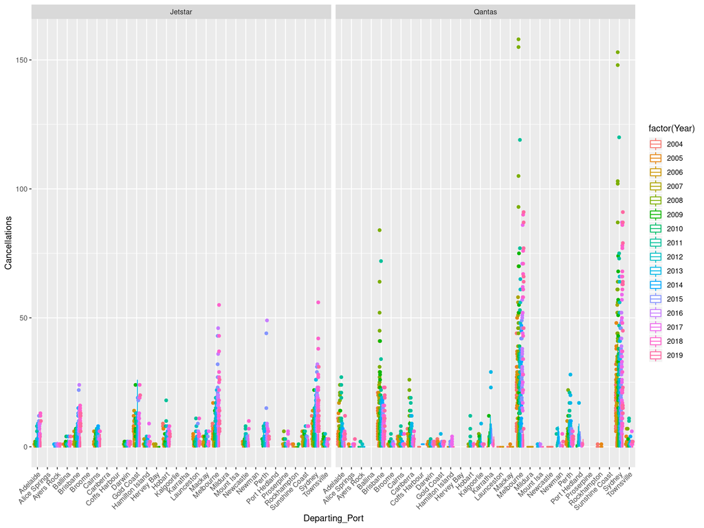

```r
p3 <- df2 %>%
        filter(Airline == "Jetstar" | Airline == "Qantas") %>%
        select(Airline, Departing_Port, Cancellations, Year) %>%
        ggplot(aes(Departing_Port, Cancellations, color = factor(Year))) +
          geom_boxplot() +
          facet_wrap(~Airline) +
          theme(axis.text.x=element_text(angle= 45, hjust=1))
p3
```

## References

- [themes](http://www.datadreaming.org/post/r-markdown-theme-gallery/)